# **Title: Melody Metrics - Predicting Popular Songs Based On Audio Features**

### **Group 09**

### **Group members**

- Prabhleen Kaur (0857194)
- Rajwinder Kaur (0831280)
- Vindya Senadheera (0857437)
- STM Chathurangi (0850982)
- Ajay Haji Korbe (0852660)

## **Import Data**

```python
#import necessary libraries
import numpy as np
import pandas as pd
import matplotlib.pyplot as plt
import seaborn as sns
```

```python
pip install openpyxl
```

```python
df = pd.read_excel(r"C:\Vindya\Data Analitics for Business\Semester 4\Capstone Project II\Dataset\Combined Spotfy Raw Data.xlsx") #read the excel dataset
```

```python
df.columns #preview the columns
```

```
Index(['track_name', 'artist_name', 'artist_popularity', 'artist_genres',
       'country_name', 'album_name', 'track_popularity', 'danceability',
       'energy', 'key', 'loudness', 'mode', 'speechiness', 'acousticness',
       'instrumentalness', 'liveness', 'valence', 'tempo', 'duration_ms',
       'time_signature'],
      dtype='object')
```

## **Understand Data**

```python
df.head() #preview first few rows
```

|  | track_name | artist_name | artist_popularity | artist_genres | country_name | album_name | track_popularity | danceability | energy | key | loudness | mode | speechiness | acousticness | instrumentalness | liveness | valence | tempo | duration_ms | time_signature |
| --- | --- | --- | --- | --- | --- | --- | --- | --- | --- | --- | --- | --- | --- | --- | --- | --- | --- | --- | --- | --- |
| 0 | Hamari Adhuri Kahani (Title Track) | Jeet Gannguli | 68 | bollywood | India | Hamari Adhuri Kahani (Original Motion Picture ... | 72 | 0.220 | 0.362 | 0 | -7.571 | 1 | 0.0316 | 0.845 | 0.000000 | 0.1330 | 0.198 | 72.516 | 398799 | 4 |
| 1 | Jo Tum Mere Ho | Anuv Jain | 75 | bollywood | India | Jo Tum Mere Ho | 83 | 0.460 | 0.302 | 1 | -12.934 | 0 | 0.0398 | 0.661 | 0.000000 | 0.2930 | 0.176 | 123.871 | 251814 | 5 |
| 2 | Aaj Bhi 2 | Vishal Mishra | 78 | bollywood | India | Aaj Bhi 2 | 69 | 0.452 | 0.328 | 1 | -11.344 | 1 | 0.0300 | 0.665 | 0.000005 | 0.1040 | 0.258 | 102.084 | 259057 | 4 |
| 3 | Agar Tum Saath Ho (From "Tamasha") | Alka Yagnik | 81 | bollywood | India | Love Forever With Arijit Singh | 69 | 0.562 | 0.519 | 3 | -8.744 | 1 | 0.0326 | 0.557 | 0.000268 | 0.1720 | 0.415 | 122.925 | 341055 | 4 |
| 4 | Tenu Sang Rakhna (From "Jigra") | Achint | 57 | bollywood | India | Tenu Sang Rakhna (From "Jigra") | 61 | 0.604 | 0.354 | 2 | -6.716 | 1 | 0.0249 | 0.845 | 0.000148 | 0.0921 | 0.277 | 110.036 | 249818 | 4 |

```python
df.info() #preview the data types
```

```
<class 'pandas.core.frame.DataFrame'>
RangeIndex: 2409 entries, 0 to 2408
Data columns (total 20 columns):
 #   Column             Non-Null Count  Dtype
---  ------             --------------  -----
 0   track_name         2408 non-null   object
 1   artist_name        2408 non-null   object
 2   artist_popularity  2409 non-null   int64
 3   artist_genres      2409 non-null   object
 4   country_name       2409 non-null   object
 5   album_name         2408 non-null   object
 6   track_popularity   2409 non-null   int64
 7   danceability       2409 non-null   float64
 8   energy             2409 non-null   float64
 9   key                2409 non-null   int64
 10  loudness           2409 non-null   float64
 11  mode               2409 non-null   int64
 12  speechiness        2409 non-null   float64
 13  acousticness       2409 non-null   float64
 14  instrumentalness   2409 non-null   float64
 15  liveness           2409 non-null   float64
 16  valence            2409 non-null   float64
 17  tempo              2409 non-null   float64
 18  duration_ms        2409 non-null   int64
 19  time_signature     2409 non-null   int64
dtypes: float64(9), int64(6), object(5)
memory usage: 376.5+ KB
```

```python
df.describe()
```

|  | artist_popularity | track_popularity | danceability | energy | key | loudness | mode | speechiness | acousticness | instrumentalness | liveness | valence | tempo | duration_ms | time_signature |
| --- | --- | --- | --- | --- | --- | --- | --- | --- | --- | --- | --- | --- | --- | --- | --- |
| count | 2409.000000 | 2409.000000 | 2409.000000 | 2409.000000 | 2409.000000 | 2409.000000 | 2409.000000 | 2409.000000 | 2409.000000 | 2409.000000 | 2409.000000 | 2409.000000 | 2409.000000 | 2409.000000 | 2409.000000 |
| mean | 58.352013 | 46.241594 | 0.616074 | 0.576756 | 5.185554 | -7.974372 | 0.631797 | 0.063945 | 0.397531 | 0.085447 | 0.163710 | 0.505344 | 119.651369 | 223337.011623 | 3.919054 |
| std | 28.375723 | 22.478777 | 0.141953 | 0.233966 | 3.557201 | 3.404541 | 0.482417 | 0.062534 | 0.327300 | 0.236692 | 0.132173 | 0.245697 | 28.277016 | 67984.785466 | 0.367500 |
| min | 0.000000 | 0.000000 | 0.213000 | 0.011900 | 0.000000 | -28.276000 | 0.000000 | 0.023100 | 0.000006 | 0.000000 | 0.021900 | 0.037000 | 53.845000 | 37702.000000 | 1.000000 |
| 25% | 35.000000 | 28.000000 | 0.515000 | 0.393000 | 2.000000 | -9.696000 | 0.000000 | 0.032700 | 0.078500 | 0.000000 | 0.094900 | 0.305000 | 98.385000 | 179587.000000 | 4.000000 |
| 50% | 64.000000 | 48.000000 | 0.621000 | 0.615000 | 5.000000 | -7.344000 | 1.000000 | 0.042700 | 0.324000 | 0.000009 | 0.115000 | 0.489000 | 117.997000 | 215213.000000 | 4.000000 |
| 75% | 83.000000 | 62.000000 | 0.723000 | 0.761000 | 8.000000 | -5.531000 | 1.000000 | 0.063700 | 0.719000 | 0.001760 | 0.179000 | 0.707000 | 135.862000 | 252466.000000 | 4.000000 |
| max | 100.000000 | 100.000000 | 0.974000 | 0.994000 | 11.000000 | -0.079000 | 1.000000 | 0.924000 | 0.992000 | 0.979000 | 0.992000 | 0.983000 | 220.081000 | 655440.000000 | 5.000000 |

```python
# Use describe to see the statistical summary
describe_data = df.describe()

# Calculate the range for each numerical column (max - min)
range_values = describe_data.loc['max'] - describe_data.loc['min']

# Display the range of each numerical column
print("Range of numerical features:")
print(range_values)
```

```
Range of numerical features:
artist_popularity       100.000000
track_popularity        100.000000
danceability              0.761000
energy                    0.982100
key                      11.000000
loudness                 28.197000
mode                      1.000000
speechiness               0.900900
acousticness              0.991994
instrumentalness          0.979000
liveness                  0.970100
valence                   0.946000
tempo                   166.236000
duration_ms          617738.000000
time_signature            4.000000
dtype: float64
```

## **Clean Data**

```python
df.isnull().sum() #check the null values
```

```
track_name           1
artist_name          1
artist_popularity    0
artist_genres        0
country_name         0
album_name           1
track_popularity     0
danceability         0
energy               0
key                  0
loudness             0
mode                 0
speechiness          0
acousticness         0
instrumentalness     0
liveness             0
valence              0
tempo                0
duration_ms          0
time_signature       0
dtype: int64
```

```python
df.shape #check the shape of the dataset
```

```
(2409, 20)
```

```python
df['artist_name'].value_counts() #get the value counts
```

```
artist_name
Criolo                    50
Jason Mraz                41
Jorge Drexler             37
BaianaSystem              29
Pritam                    27
                          ..
MoBlack                    1
Abdou Gambetta             1
Abdul Majeed Abdullah      1
Saif Nabeel                1
Limoblaze;Dj Horphuray     1
Name: count, Length: 927, dtype: int64
```

```python
# prompt: need to remove null values

df.dropna(inplace=True)
df.isnull().sum()
df.shape
```

```
(2408, 20)
```

```python
df.isnull().sum() #check the null values afater removing
```

```
track_name           0
artist_name          0
artist_popularity    0
artist_genres        0
country_name         0
album_name           0
track_popularity     0
danceability         0
energy               0
key                  0
loudness             0
mode                 0
speechiness          0
acousticness         0
instrumentalness     0
liveness             0
valence              0
tempo                0
duration_ms          0
time_signature       0
dtype: int64
```

```python
# Find all duplicate rows
duplicates = df[df.duplicated()]
duplicates
```

|  | track_name | artist_name | artist_popularity | artist_genres | country_name | album_name | track_popularity | danceability | energy | key | loudness | mode | speechiness | acousticness | instrumentalness | liveness | valence | tempo | duration_ms | time_signature |
| --- | --- | --- | --- | --- | --- | --- | --- | --- | --- | --- | --- | --- | --- | --- | --- | --- | --- | --- | --- | --- |
| 66 | Aaj Bhi 2 | Vishal Mishra | 78 | bollywood | India | Aaj Bhi 2 | 69 | 0.452 | 0.328 | 1 | -11.344 | 1 | 0.0300 | 0.66500 | 0.000005 | 0.1040 | 0.258 | 102.084 | 259057 | 4 |
| 78 | Children of the Sun | Alan Walker | 82 | acoustic | Norway | Children of the Sun | 59 | 0.594 | 0.777 | 2 | -4.552 | 1 | 0.0310 | 0.27300 | 0.000040 | 0.1120 | 0.318 | 130.982 | 218070 | 4 |
| 80 | Yeh Dil Deewana | Sonu Nigam | 77 | bollywood | India | Yeh Dil Deewana | 14 | 0.590 | 0.678 | 0 | -6.047 | 1 | 0.0522 | 0.75600 | 0.000002 | 0.0586 | 0.757 | 89.979 | 209064 | 4 |
| 86 | Vekh Sohneyaa - From "Call Me Bae" | Bombay the Artist | 56 | bollywood | India | Vekh Sohneyaa (From "Call Me Bae") | 68 | 0.715 | 0.673 | 4 | -4.860 | 0 | 0.0593 | 0.27300 | 0.000000 | 0.1460 | 0.615 | 114.968 | 216465 | 4 |
| 87 | Kinni Soni | Darshan Raval | 77 | bollywood | India | Kinni Soni | 65 | 0.678 | 0.631 | 4 | -6.866 | 0 | 0.0443 | 0.47000 | 0.000031 | 0.0971 | 0.222 | 104.017 | 241201 | 4 |
| ... | ... | ... | ... | ... | ... | ... | ... | ... | ... | ... | ... | ... | ... | ... | ... | ... | ... | ... | ... | ... |
| 745 | 360 | Charli xcx | 89 | pop | United Kingdom | 360 | 62 | 0.857 | 0.620 | 0 | -8.130 | 1 | 0.0472 | 0.64600 | 0.244000 | 0.0934 | 0.796 | 120.042 | 133805 | 4 |
| 746 | You’re Losing Me (From The Vault) | Taylor Swift | 100 | pop | United States | You're Losing Me (From The Vault) | 75 | 0.744 | 0.396 | 0 | -13.712 | 1 | 0.0570 | 0.50900 | 0.003190 | 0.1210 | 0.180 | 102.969 | 277832 | 4 |
| 747 | Summer's Gone | Monoir | 46 | pop | Romania | Summer's Gone | 51 | 0.858 | 0.782 | 9 | -3.569 | 1 | 0.0474 | 0.00568 | 0.011700 | 0.1480 | 0.185 | 127.967 | 152827 | 4 |
| 748 | older | Isabel LaRosa | 76 | pop | United States | older | 78 | 0.466 | 0.510 | 3 | -7.310 | 0 | 0.0348 | 0.08420 | 0.000002 | 0.0912 | 0.418 | 67.513 | 137778 | 4 |
| 749 | Bad Feeling (Oompa Loompa) | Jagwar Twin | 63 | pop | United States | Bad Feeling (Oompa Loompa) | 43 | 0.699 | 0.806 | 11 | -3.907 | 0 | 0.1180 | 0.08800 | 0.000000 | 0.0770 | 0.903 | 189.835 | 133755 | 4 |

185 rows × 20 columns

```python
spotify = df.drop_duplicates()
spotify
```

|  | track_name | artist_name | artist_popularity | artist_genres | country_name | album_name | track_popularity | danceability | energy | key | loudness | mode | speechiness | acousticness | instrumentalness | liveness | valence | tempo | duration_ms | time_signature |
| --- | --- | --- | --- | --- | --- | --- | --- | --- | --- | --- | --- | --- | --- | --- | --- | --- | --- | --- | --- | --- |
| 0 | Hamari Adhuri Kahani (Title Track) | Jeet Gannguli | 68 | bollywood | India | Hamari Adhuri Kahani (Original Motion Picture ... | 72 | 0.220 | 0.362 | 0 | -7.571 | 1 | 0.0316 | 0.84500 | 0.000000 | 0.1330 | 0.198 | 72.516 | 398799 | 4 |
| 1 | Jo Tum Mere Ho | Anuv Jain | 75 | bollywood | India | Jo Tum Mere Ho | 83 | 0.460 | 0.302 | 1 | -12.934 | 0 | 0.0398 | 0.66100 | 0.000000 | 0.2930 | 0.176 | 123.871 | 251814 | 5 |
| 2 | Aaj Bhi 2 | Vishal Mishra | 78 | bollywood | India | Aaj Bhi 2 | 69 | 0.452 | 0.328 | 1 | -11.344 | 1 | 0.0300 | 0.66500 | 0.000005 | 0.1040 | 0.258 | 102.084 | 259057 | 4 |
| 3 | Agar Tum Saath Ho (From "Tamasha") | Alka Yagnik | 81 | bollywood | India | Love Forever With Arijit Singh | 69 | 0.562 | 0.519 | 3 | -8.744 | 1 | 0.0326 | 0.55700 | 0.000268 | 0.1720 | 0.415 | 122.925 | 341055 | 4 |
| 4 | Tenu Sang Rakhna (From "Jigra") | Achint | 57 | bollywood | India | Tenu Sang Rakhna (From "Jigra") | 61 | 0.604 | 0.354 | 2 | -6.716 | 1 | 0.0249 | 0.84500 | 0.000148 | 0.0921 | 0.277 | 110.036 | 249818 | 4 |
| ... | ... | ... | ... | ... | ... | ... | ... | ... | ... | ... | ... | ... | ... | ... | ... | ... | ... | ... | ... | ... |
| 2404 | You Are My Heart | Rex Williams | 56 | afrobeat | Brazil | Nigeria 70 - Lagos Jump | 46 | 0.675 | 0.681 | 7 | -7.458 | 1 | 0.0364 | 0.48100 | 0.023200 | 0.2250 | 0.604 | 97.442 | 193000 | 4 |
| 2405 | Anbessa | Akalé Wubé;Manu Dibango | 69 | afrobeat | Brazil | Sost | 49 | 0.820 | 0.473 | 10 | -7.300 | 0 | 0.0454 | 0.29300 | 0.861000 | 0.1360 | 0.645 | 120.066 | 221720 | 4 |
| 2406 | Old Engine Oil | The Budos Band | 94 | afrobeat | Brazil | V | 40 | 0.366 | 0.910 | 2 | -6.157 | 1 | 0.0415 | 0.00119 | 0.834000 | 0.1010 | 0.322 | 92.940 | 191213 | 4 |
| 2407 | Amoureux | Ilover | 84 | afrobeat | Brazil | Amoureux | 20 | 0.703 | 0.859 | 6 | -3.991 | 1 | 0.0752 | 0.22200 | 0.000000 | 0.1740 | 0.867 | 82.069 | 228115 | 4 |
| 2408 | Your Love | Limoblaze;Dj Horphuray | 15 | afrobeat | Brazil | Afrobeats Rap and Jesus | 42 | 0.795 | 0.719 | 6 | -4.791 | 1 | 0.0642 | 0.11500 | 0.005100 | 0.0525 | 0.958 | 110.020 | 224208 | 4 |

2223 rows × 20 columns

```python
# Check the data types to identify numerical columns
print(spotify.dtypes)
```

```
track_name            object
artist_name           object
artist_popularity      int64
artist_genres         object
country_name          object
album_name            object
track_popularity       int64
danceability         float64
energy               float64
key                    int64
loudness             float64
mode                   int64
speechiness          float64
acousticness         float64
instrumentalness     float64
liveness             float64
valence              float64
tempo                float64
duration_ms            int64
time_signature         int64
dtype: object
```

## **Check and Remove the Outliers**

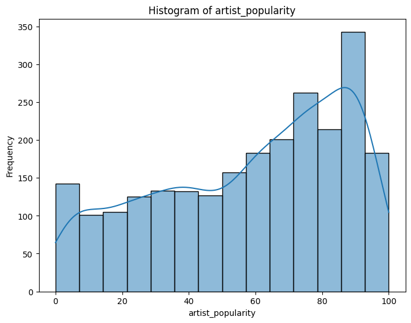

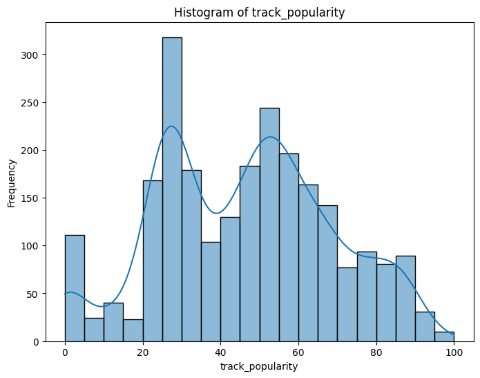

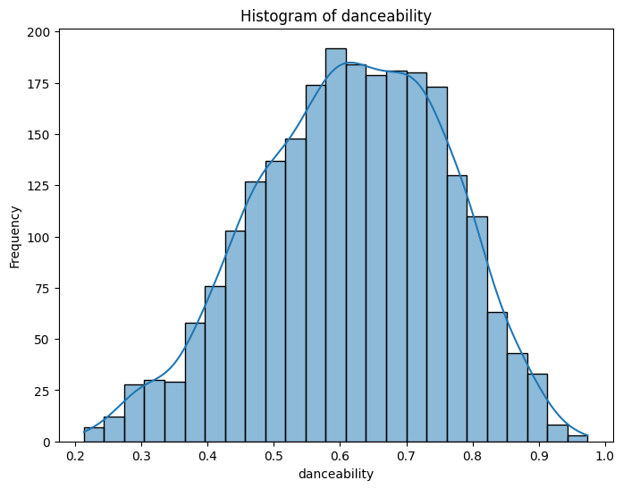

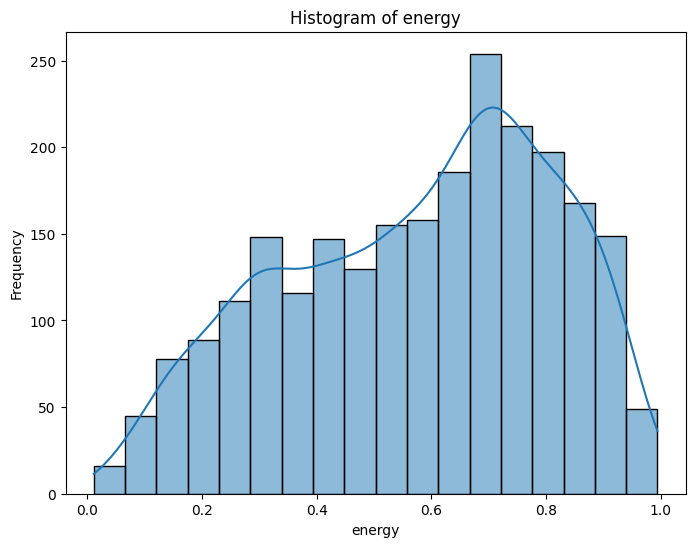

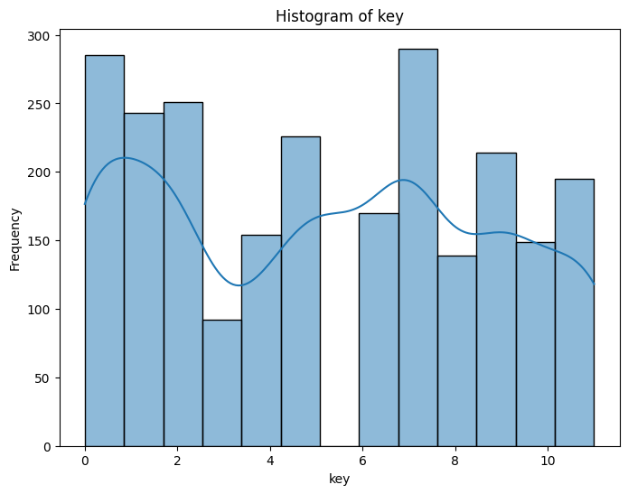

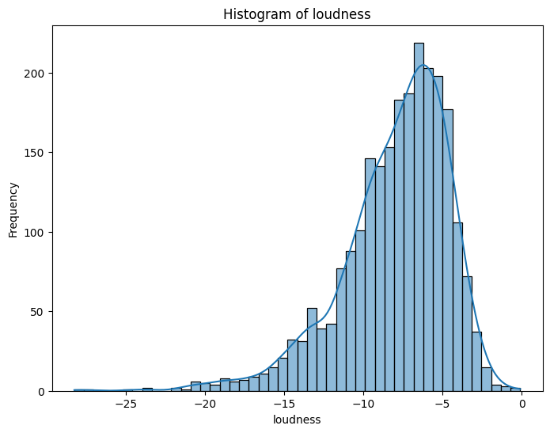

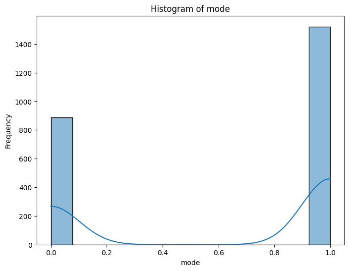

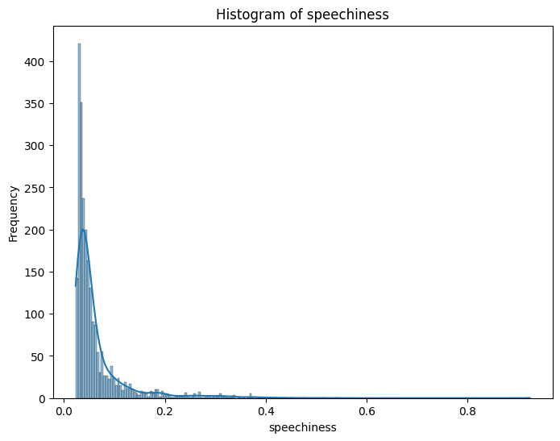

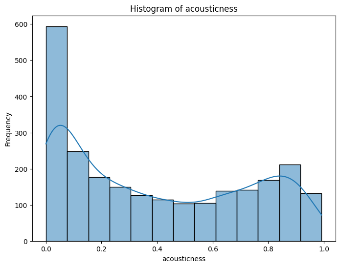

[figure not shown]

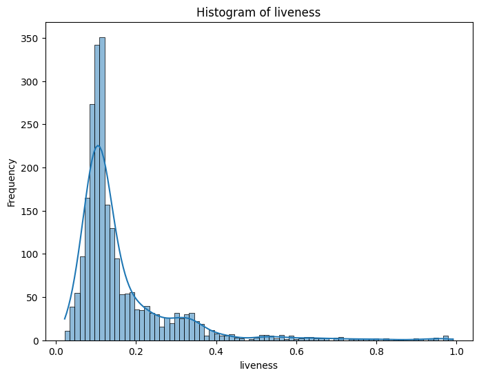

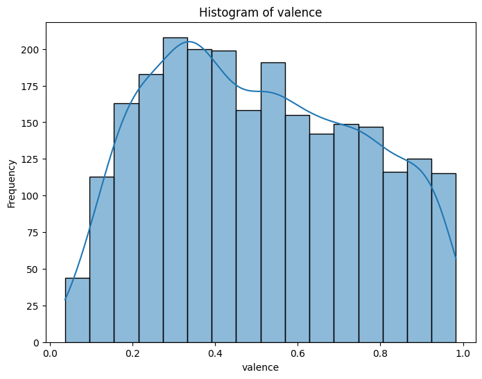

[3 more figures not shown]

```python
# plotting Histogram
numeric_cols = spotify.select_dtypes(include=np.number).columns

for col in numeric_cols:
    plt.figure(figsize=(8, 6))  # Adjust figure size if needed
    sns.histplot(df[col], kde=True)  # kde=True adds a kernel density estimate
    plt.title(f'Histogram of {col}')
    plt.xlabel(col)
    plt.ylabel('Frequency')
    plt.show()
```

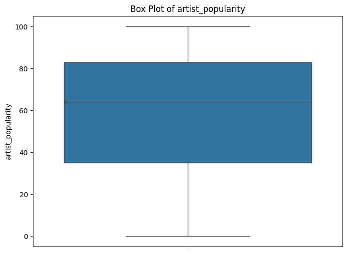

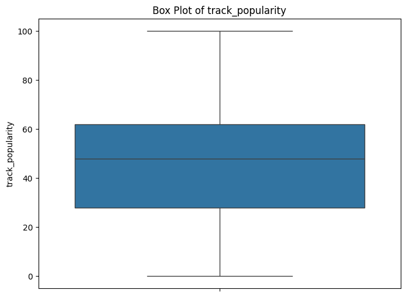

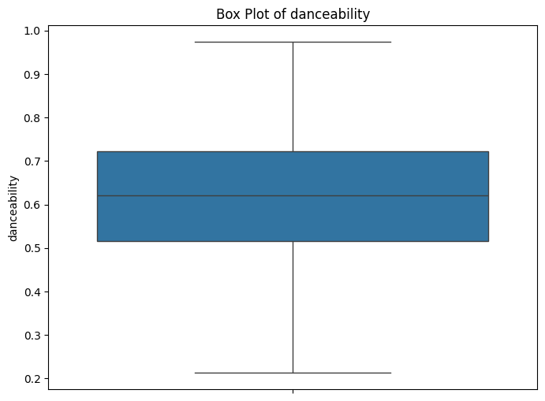

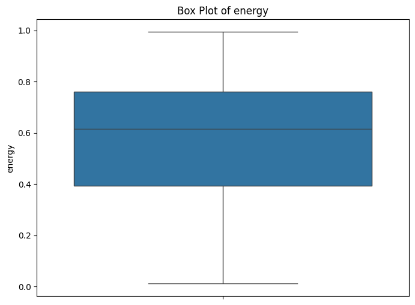

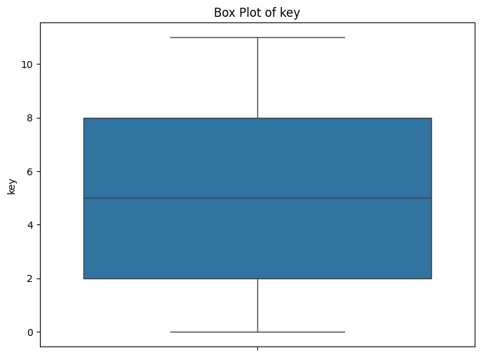

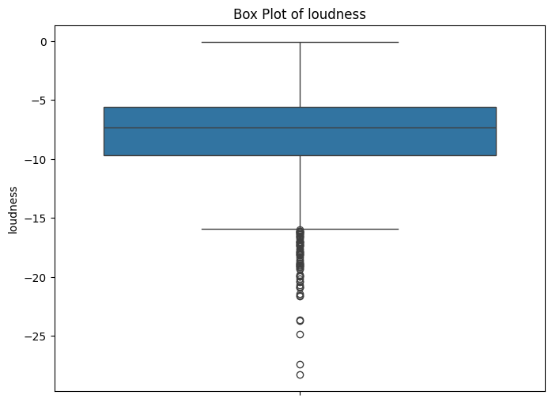

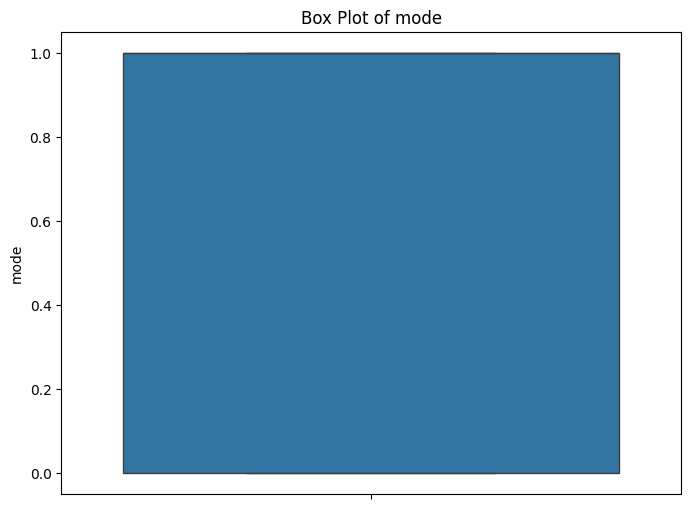

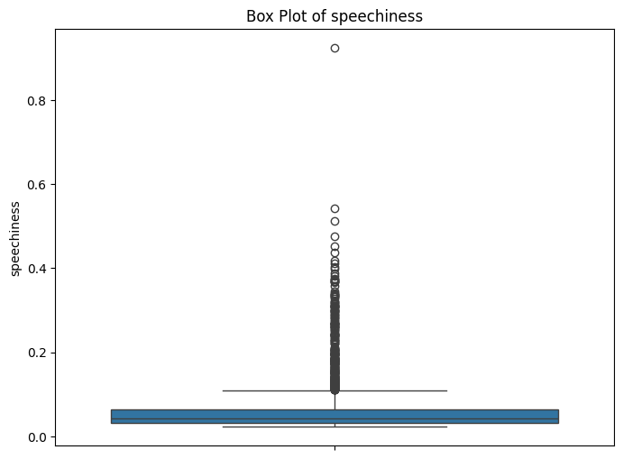

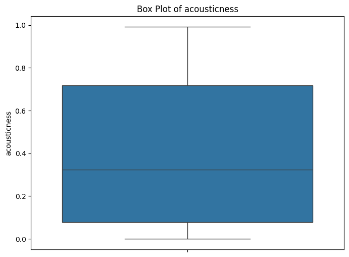

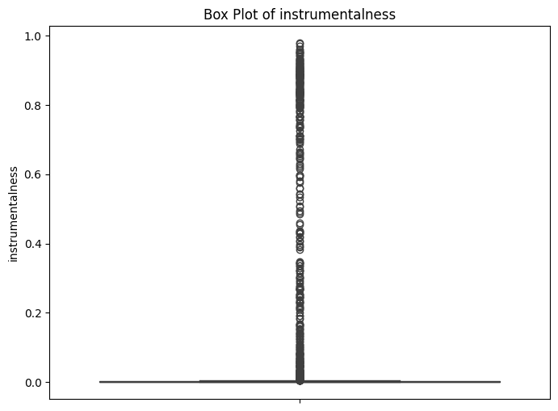

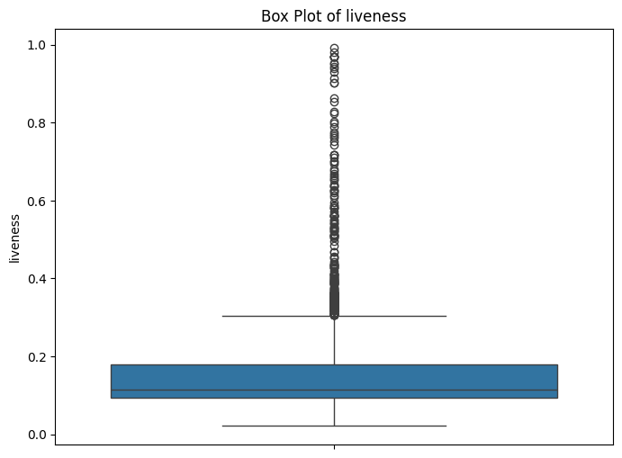

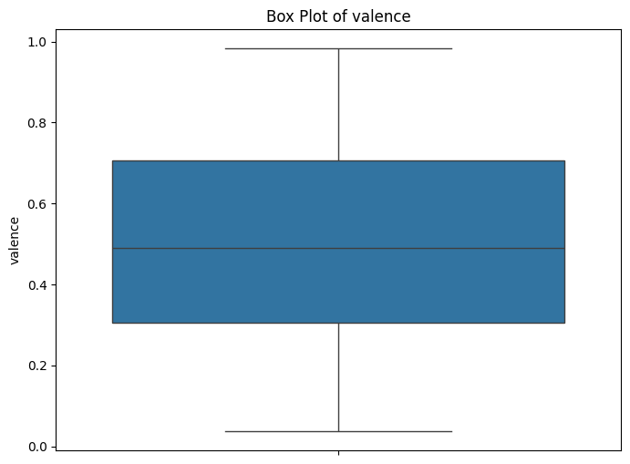

[3 more figures not shown]

```python
# plotting Box plot
numeric_cols = spotify.select_dtypes(include=np.number).columns

for col in numeric_cols:
    plt.figure(figsize=(8, 6))  # Adjust figure size if needed
    sns.boxplot(y=df[col])  # Use sns.boxplot for box plots
    plt.title(f'Box Plot of {col}')
    plt.ylabel(col)
    plt.show()
```

```python
# Function to remove outliers using IQR for a specific column
def remove_outliers_iqr(spotify, column):
    Q1 = spotify[column].quantile(0.25)
    Q3 = spotify[column].quantile(0.75)
    IQR = Q3 - Q1
    lower_bound = Q1 - 1.5 * IQR
    upper_bound = Q3 + 1.5 * IQR
    spotify_filtered = spotify[(spotify[column] >= lower_bound) & (spotify[column] <= upper_bound)]
    return spotify_filtered

# List of columns to check for outliers
columns_to_check = [
    'danceability', 'loudness', 'speechiness', 'acousticness',
    'instrumentalness', 'liveness', 'time_signature', 'tempo',
    'duration_ms', 'track_popularity'
]

# Iterate over all specified columns and apply the outlier removal function
spotify_no_outliers = spotify.copy()  # Make a copy to avoid modifying the original dataframe
for col in columns_to_check:
    spotify_no_outliers = remove_outliers_iqr(spotify_no_outliers, col)

# Check the shape of the DataFrame after outlier removal
print(spotify_no_outliers.shape)
```

```
(1177, 20)
```

```python
# final data after removing outliers

spotify_no_outliers.head()
```

|  | track_name | artist_name | artist_popularity | artist_genres | country_name | album_name | track_popularity | danceability | energy | key | loudness | mode | speechiness | acousticness | instrumentalness | liveness | valence | tempo | duration_ms | time_signature |
| --- | --- | --- | --- | --- | --- | --- | --- | --- | --- | --- | --- | --- | --- | --- | --- | --- | --- | --- | --- | --- |
| 2 | Aaj Bhi 2 | Vishal Mishra | 78 | bollywood | India | Aaj Bhi 2 | 69 | 0.452 | 0.328 | 1 | -11.344 | 1 | 0.0300 | 0.665 | 0.000005 | 0.1040 | 0.258 | 102.084 | 259057 | 4 |
| 3 | Agar Tum Saath Ho (From "Tamasha") | Alka Yagnik | 81 | bollywood | India | Love Forever With Arijit Singh | 69 | 0.562 | 0.519 | 3 | -8.744 | 1 | 0.0326 | 0.557 | 0.000268 | 0.1720 | 0.415 | 122.925 | 341055 | 4 |
| 4 | Tenu Sang Rakhna (From "Jigra") | Achint | 57 | bollywood | India | Tenu Sang Rakhna (From "Jigra") | 61 | 0.604 | 0.354 | 2 | -6.716 | 1 | 0.0249 | 0.845 | 0.000148 | 0.0921 | 0.277 | 110.036 | 249818 | 4 |
| 7 | Ae Dil Hai Mushkil Title Track | Pritam | 89 | bollywood | India | Ae Dil Hai Mushkil (Original Motion Picture So... | 70 | 0.495 | 0.654 | 3 | -6.639 | 0 | 0.0679 | 0.713 | 0.000000 | 0.1650 | 0.350 | 123.896 | 269032 | 4 |
| 8 | Vekh Sohneyaa - From "Call Me Bae" | Bombay the Artist | 56 | bollywood | India | Vekh Sohneyaa (From "Call Me Bae") | 68 | 0.715 | 0.673 | 4 | -4.860 | 0 | 0.0593 | 0.273 | 0.000000 | 0.1460 | 0.615 | 114.968 | 216465 | 4 |

## **Exploratory Data Analysis (EDA)**

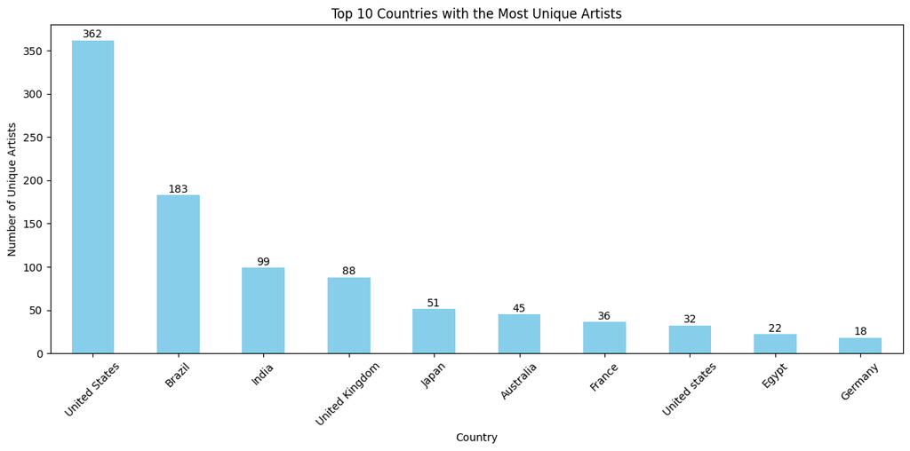

```python
# Count the number of unique artists per country
artist_count_by_country = spotify.groupby('country_name')['artist_name'].nunique().sort_values(ascending=False)

# Plot the combined bar chart for the top 10 countries with the most unique artists
plt.figure(figsize=(12, 6))
artist_count_by_country.head(10).plot(kind='bar', color='skyblue')

# Add labels and title to the plot
plt.title('Top 10 Countries with the Most Unique Artists')
plt.xlabel('Country')
plt.ylabel('Number of Unique Artists')
plt.xticks(rotation=45)

# Display the count of unique artists on top of the bars
for i, value in enumerate(artist_count_by_country.head(10)):
    plt.text(i, value + 0.5, str(value), ha='center', va='bottom', fontsize=10)

# Show the plot
plt.tight_layout()
plt.show()
```

```python
# separate numerical and categorical after removing time_signature column

# Drop the 'time_signature' column if it exists
if 'time_signature' in spotify_no_outliers.columns:
    spotify_no_outliers = spotify_no_outliers.drop('time_signature', axis=1)

# Separate numerical and categorical features
numerical_features = spotify_no_outliers.select_dtypes(include=np.number).columns
categorical_features = spotify_no_outliers.select_dtypes(exclude=np.number).columns

# Print or further process the separated features
print("Numerical features:", numerical_features)
print("Categorical features:", categorical_features)

# Example: Create new DataFrames for numerical and categorical features
numerical_spotify = spotify_no_outliers[numerical_features]
categorical_spotify = spotify_no_outliers[categorical_features]

print(numerical_spotify.head())
print(categorical_spotify.head())
```

```
Numerical features: Index(['artist_popularity', 'track_popularity', 'danceability', 'energy',
       'key', 'loudness', 'mode', 'speechiness', 'acousticness',
       'instrumentalness', 'liveness', 'valence', 'tempo', 'duration_ms'],
      dtype='object')
Categorical features: Index(['track_name', 'artist_name', 'artist_genres', 'country_name',
       'album_name'],
      dtype='object')
   artist_popularity  track_popularity  danceability  energy  key  loudness  \
2                 78                69         0.452   0.328    1   -11.344
3                 81                69         0.562   0.519    3    -8.744
4                 57                61         0.604   0.354    2    -6.716
7                 89                70         0.495   0.654    3    -6.639
8                 56                68         0.715   0.673    4    -4.860

   mode  speechiness  acousticness  instrumentalness  liveness  valence  \
2     1       0.0300         0.665          0.000005    0.1040    0.258
3     1       0.0326         0.557          0.000268    0.1720    0.415
4     1       0.0249         0.845          0.000148    0.0921    0.277
7     0       0.0679         0.713          0.000000    0.1650    0.350
8     0       0.0593         0.273          0.000000    0.1460    0.615

     tempo  duration_ms
2  102.084       259057
3  122.925       341055
4  110.036       249818
7  123.896       269032
8  114.968       216465
                           track_name        artist_name artist_genres  \
2                           Aaj Bhi 2      Vishal Mishra     bollywood
3  Agar Tum Saath Ho (From "Tamasha")        Alka Yagnik     bollywood
4     Tenu Sang Rakhna (From "Jigra")             Achint     bollywood
7      Ae Dil Hai Mushkil Title Track             Pritam     bollywood
8  Vekh Sohneyaa - From "Call Me Bae"  Bombay the Artist     bollywood

  country_name                                         album_name
2        India                                          Aaj Bhi 2
3        India                     Love Forever With Arijit Singh
4        India                    Tenu Sang Rakhna (From "Jigra")
7        India  Ae Dil Hai Mushkil (Original Motion Picture So...
8        India                 Vekh Sohneyaa (From "Call Me Bae")
```

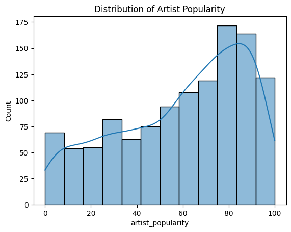

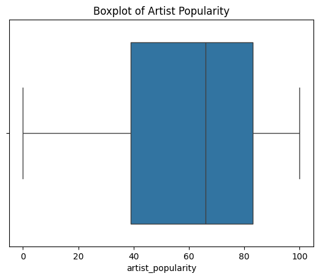

```python
# Example: Visualizing the distribution of artist popularity
sns.histplot(spotify_no_outliers['artist_popularity'], kde=True)
plt.title('Distribution of Artist Popularity')
plt.show()

# Boxplot for artist popularity
sns.boxplot(x=spotify_no_outliers['artist_popularity'])
plt.title('Boxplot of Artist Popularity')
plt.show()
```

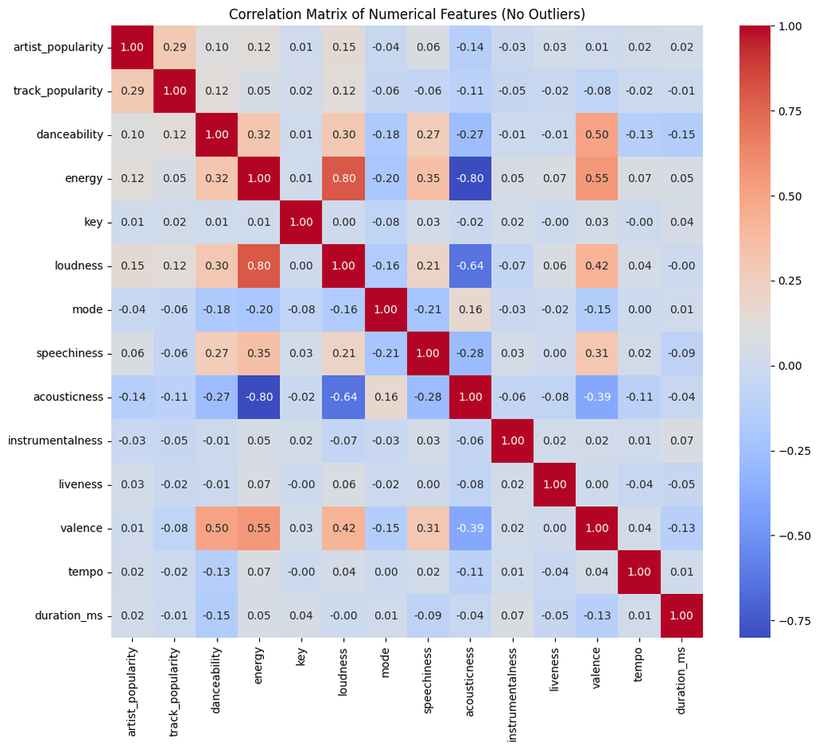

```python
# Calculate the correlation matrix for numerical features in spotify_no_outliers
numerical_spotify_no_outliers = spotify_no_outliers.select_dtypes(include=np.number)

# Calculate the correlation matrix
correlation_matrix = numerical_spotify_no_outliers.corr()

# Plot the correlation matrix as a heatmap
plt.figure(figsize=(12, 10))
sns.heatmap(correlation_matrix, annot=True, cmap='coolwarm', fmt=".2f")
plt.title('Correlation Matrix of Numerical Features (No Outliers)')
plt.show()
```

```python
# Calculate the correlation matrix for numerical features in spotify_no_outliers
numerical_spotify_no_outliers = spotify_no_outliers.select_dtypes(include=np.number)

# Calculate the correlation matrix
correlation_matrix = numerical_spotify_no_outliers.corr()

# Get the absolute correlation values for 'track_popularity' and sort them
correlation_with_popularity = correlation_matrix['track_popularity'].abs().sort_values(ascending=False)

# Display the correlation values
print(correlation_with_popularity)
```

```
track_popularity     1.000000
artist_popularity    0.290006
loudness             0.120844
danceability         0.120702
acousticness         0.107754
valence              0.081506
speechiness          0.057225
mode                 0.055120
energy               0.053824
instrumentalness     0.047217
liveness             0.020520
key                  0.020356
tempo                0.018604
duration_ms          0.012904
Name: track_popularity, dtype: float64
```

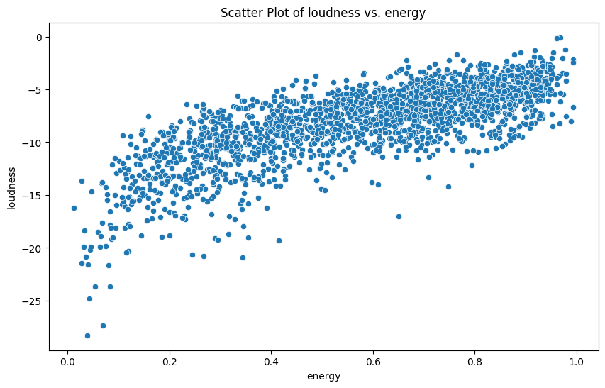

```python
# Set the dependent variable
y = spotify['loudness']

# Choose an independent variable
x = spotify['energy']

# Create the scatter plot
plt.figure(figsize=(10, 6))
sns.scatterplot(x=x, y=y, data=spotify)
plt.title('Scatter Plot of loudness vs. energy')
plt.xlabel('energy')
plt.ylabel('loudness')
plt.show()
```

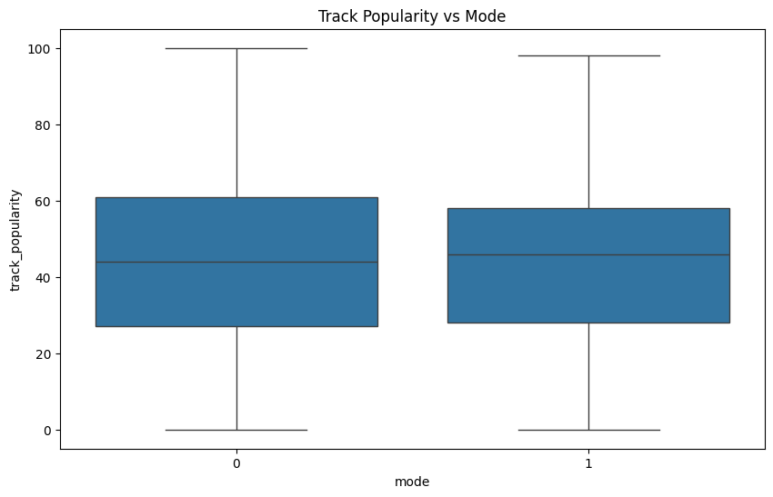

```python
plt.figure(figsize=(10, 6))
sns.boxplot(x='mode', y='track_popularity', data=spotify)
plt.title('Track Popularity vs Mode')
plt.show()
```

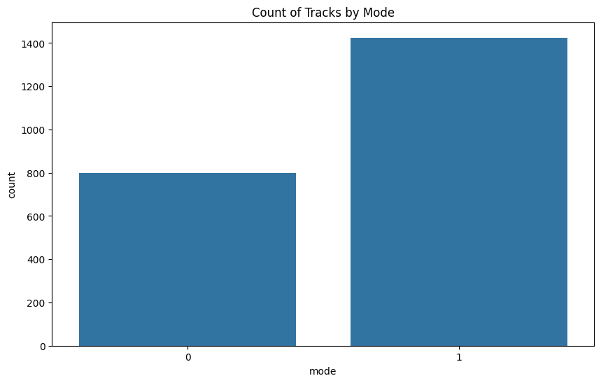

```python
plt.figure(figsize=(10, 6))
sns.countplot(x='mode', data=spotify)
plt.title('Count of Tracks by Mode')
plt.show()
```

```python
spotify_no_outliers.columns
```

```
Index(['track_name', 'artist_name', 'artist_popularity', 'artist_genres',
       'country_name', 'album_name', 'track_popularity', 'danceability',
       'energy', 'key', 'loudness', 'mode', 'speechiness', 'acousticness',
       'instrumentalness', 'liveness', 'valence', 'tempo', 'duration_ms'],
      dtype='object')
```

```python
spotify_no_outliers.describe() #summary of the statistical properties of numerical columns in the DataFrame
```

|  | artist_popularity | track_popularity | danceability | energy | key | loudness | mode | speechiness | acousticness | instrumentalness | liveness | valence | tempo | duration_ms |
| --- | --- | --- | --- | --- | --- | --- | --- | --- | --- | --- | --- | --- | --- | --- |
| count | 1177.000000 | 1177.000000 | 1177.000000 | 1177.000000 | 1177.000000 | 1177.000000 | 1177.000000 | 1177.000000 | 1177.000000 | 1177.000000 | 1177.000000 | 1177.000000 | 1177.000000 | 1177.000000 |
| mean | 59.547154 | 47.484282 | 0.613598 | 0.548810 | 5.067120 | -7.652804 | 0.683942 | 0.045884 | 0.432164 | 0.000308 | 0.128631 | 0.498331 | 116.881681 | 215764.979609 |
| std | 27.736639 | 21.619899 | 0.136645 | 0.233113 | 3.583752 | 3.011698 | 0.465133 | 0.020002 | 0.324868 | 0.000944 | 0.053878 | 0.235628 | 26.417263 | 46616.078909 |
| min | 0.000000 | 0.000000 | 0.228000 | 0.011900 | 0.000000 | -16.177000 | 0.000000 | 0.023200 | 0.000006 | 0.000000 | 0.021900 | 0.056800 | 53.845000 | 86984.000000 |
| 25% | 39.000000 | 30.000000 | 0.516000 | 0.340000 | 2.000000 | -9.573000 | 0.000000 | 0.031300 | 0.108000 | 0.000000 | 0.095100 | 0.308000 | 96.900000 | 181482.000000 |
| 50% | 66.000000 | 50.000000 | 0.620000 | 0.572000 | 5.000000 | -7.050000 | 1.000000 | 0.038500 | 0.395000 | 0.000001 | 0.112000 | 0.472000 | 115.067000 | 214860.000000 |
| 75% | 83.000000 | 62.000000 | 0.715000 | 0.744000 | 8.000000 | -5.416000 | 1.000000 | 0.054200 | 0.759000 | 0.000063 | 0.147000 | 0.688000 | 133.737000 | 246786.000000 |
| max | 100.000000 | 95.000000 | 0.960000 | 0.972000 | 11.000000 | -1.294000 | 1.000000 | 0.112000 | 0.972000 | 0.006970 | 0.301000 | 0.975000 | 187.057000 | 346291.000000 |

## **Statistical Analysis**

### **Example 1:**

**ANOVA (Analysis of Variance) Test**

**Hypothesis Statement: whether there's a difference in track popularity across different genres**

- Null Hypothesis: There is no significant difference in track popularity across the different genres.
- Alternative hypothesis : There is a significant difference in track popularity across different genres.

We can use **ANOVA (Analysis of Variance)** beacuse it is used to compare means across three or more groups.

```python
import pandas as pd
from scipy import stats

# Group the data by genre
genres = spotify_no_outliers['artist_genres'].unique()  # This gives a list of all unique genres in your dataset

# Create a list to hold the track popularity for each genre
track_popularity_by_genre = []

# Loop through each genre and get the track popularity values
for genre in genres:
    track_popularity_by_genre.append(spotify_no_outliers[spotify_no_outliers['artist_genres'] == genre]['track_popularity'])

# Perform the ANOVA test
f_stat, p_value = stats.f_oneway(*track_popularity_by_genre)

# Print the results
print("F-statistic:", f_stat)
print("P-value:", p_value)

# Interpret the results
alpha = 0.05
if p_value < alpha:
    print("Reject the null hypothesis: Track popularity differs across genres.")
else:
    print("Fail to reject the null hypothesis: Track popularity does not differ across genres.")
```

```
F-statistic: 27.876408398911984
P-value: 2.9891657791355696e-81
Reject the null hypothesis: Track popularity differs across genres.
```

### **Example 2:**

**Pearson Correlation test**

- Null Hypothesis : There is no correlation between track popularity and the feature.
- Alternative Hypothesis : There is a significant correlation between track popularity and the feature.

The **Pearson correlation test** is a statistical method used to measure the linear relationship between two continuous variables

```python
from scipy.stats import pearsonr

features = ['loudness', 'danceability', 'energy', 'acousticness']  #  features

# For each feature, calculate Pearson correlation with track popularity
for feature in features:
    corr, p_value = pearsonr(spotify_no_outliers[feature], spotify_no_outliers['track_popularity'])
    print(f"Correlation between {feature} and track popularity: {corr}, p-value: {p_value}")

    # Interpret the results
    if p_value < 0.05:
        print(f"Reject the null hypothesis: There is a significant relationship between {feature} and track popularity.")
    else:
        print(f"Fail to reject the null hypothesis: There is no significant relationship between {feature} and track popularity.")
```

```
Correlation between loudness and track popularity: 0.12084407864081562, p-value: 3.228964251822671e-05
Reject the null hypothesis: There is a significant relationship between loudness and track popularity.
Correlation between danceability and track popularity: 0.12070188594196099, p-value: 3.299288607374593e-05
Reject the null hypothesis: There is a significant relationship between danceability and track popularity.
Correlation between energy and track popularity: 0.05382414060656092, p-value: 0.06490030159980965
Fail to reject the null hypothesis: There is no significant relationship between energy and track popularity.
Correlation between acousticness and track popularity: -0.10775383601878671, p-value: 0.00021254658934488727
Reject the null hypothesis: There is a significant relationship between acousticness and track popularity.
```

- Songs with higher loudness tend to be slightly more popular.
- Songs with higher danceability tend to be slightly more popular.
- Energy has a negligible relationship with track popularity.
- Songs with higher acousticness tend to be slightly less popular.

### **Example 3:**

**T Test**

- Null Hypothesis: There is no difference in danceability between popular and unpopular songs.
- Alternative Hypothesis: Popular songs have higher danceability than unpopular songs.

```python
import pandas as pd
import numpy as np
from scipy.stats import t

# Define popular and unpopular songs
popularity_threshold = 48
spotify_no_outliers['popularity_category'] = spotify_no_outliers['track_popularity'].apply(lambda x: 'Popular' if x >= popularity_threshold else 'Unpopular')

# Separate data into two groups
popular_songs = spotify_no_outliers[spotify_no_outliers['popularity_category'] == 'Popular']
unpopular_songs = spotify_no_outliers[spotify_no_outliers['popularity_category'] == 'Unpopular']

# Calculate sample statistics
mean_popular = np.mean(popular_songs['danceability'])
mean_unpopular = np.mean(unpopular_songs['danceability'])
std_popular = np.std(popular_songs['danceability'], ddof=1)
std_unpopular = np.std(unpopular_songs['danceability'], ddof=1)
n_popular = len(popular_songs)
n_unpopular = len(unpopular_songs)

# Compute standard error
se = np.sqrt((std_popular**2 / n_popular) + (std_unpopular**2 / n_unpopular))

# Compute t-statistic
t_stat = (mean_popular - mean_unpopular) / se

# Compute degrees of freedom
df = ( (std_popular**2 / n_popular + std_unpopular**2 / n_unpopular) ** 2 ) / ( ((std_popular**2 / n_popular) ** 2) / (n_popular - 1) + ((std_unpopular**2 / n_unpopular) ** 2) / (n_unpopular - 1) )

# Compute one-tailed p-value
p_value = 1 - t.cdf(t_stat, df)

# Results
print("One-Tailed Danceability t-test:")
print(f"t-statistic: {t_stat:.4f}")
print(f"Degrees of freedom: {df:.4f}")
print(f"p-value: {p_value:.4f}")

alpha = 0.05
if p_value < alpha:
    print("Reject the null hypothesis: Popular songs have significantly higher danceability than unpopular songs.")
else:
    print("Fail to reject the null hypothesis: No significant evidence that popular songs have higher danceability.")
```

```
One-Tailed Danceability t-test:
t-statistic: 2.6409
Degrees of freedom: 1157.4482
p-value: 0.0042
Reject the null hypothesis: Popular songs have significantly higher danceability than unpopular songs.
```

## **Feature Selection**

### **Method 1: Filter Method (Chi-Square)**

```python
categorical_columns = ['artist_genres', 'country_name', 'album_name','track_name','artist_name']  # Add categorical columns here
spotify_encoded = pd.get_dummies(spotify_no_outliers[categorical_columns], drop_first=True)
```

H0: There is no significant relationship between features and Popularity

Ha: There is significant relationship between feature and popuarity.

```python
from scipy.stats import chi2_contingency

# Loop through each categorical feature
for feature in categorical_columns:
    # Create a contingency table for each feature and target variable
    contingency_table = pd.crosstab(spotify_no_outliers[feature], spotify_no_outliers['popularity_category'])

    # Perform Chi-Square Test
    chi2, p_value, dof, expected = chi2_contingency(contingency_table)

    # Print results
    print(f"Chi-Square for {feature} vs popularity_category: p-value = {p_value}")

    # Interpretation based on p-value
    if p_value < 0.05:
        print(f"Reject the null hypothesis: There is a significant relationship between {feature} and  popularity.")
    else:
        print(f"Fail to reject the null hypothesis: No significant relationship between {feature} and popularity.")
```

```
Chi-Square for artist_genres vs popularity_category: p-value = 4.037985756033505e-47
Reject the null hypothesis: There is a significant relationship between artist_genres and  popularity.
Chi-Square for country_name vs popularity_category: p-value = 3.6724078947458966e-33
Reject the null hypothesis: There is a significant relationship between country_name and  popularity.
Chi-Square for album_name vs popularity_category: p-value = 1.6076002084069228e-05
Reject the null hypothesis: There is a significant relationship between album_name and  popularity.
Chi-Square for track_name vs popularity_category: p-value = 0.05178815111679317
Fail to reject the null hypothesis: No significant relationship between track_name and popularity.
Chi-Square for artist_name vs popularity_category: p-value = 2.3856639187831007e-19
Reject the null hypothesis: There is a significant relationship between artist_name and  popularity.
```

### **Method 2: Wrapper method**

RFE works by recursively removing features and building a model on the remaining features. It uses model performance to evaluate which features are most important.

Wrapper methods evaluate subsets of features by training a model multiple times and iteratively eliminating less important features.

```python
# Drop the 'track_name' column since it does not have a significant relationship with track popularity
spotify_no_outliers = spotify_no_outliers.drop(columns=['track_name'])

# Check the shape after dropping the column
print("Shape after dropping 'track_name':", spotify_no_outliers.shape)
```

```
Shape after dropping 'track_name': (1177, 19)
```

```python
from sklearn.preprocessing import LabelEncoder

# Initialize the label encoder
label_encoder = LabelEncoder()

# Apply label encoding to all categorical columns
categorical_columns = ['artist_name', 'artist_genres', 'country_name', 'album_name']  # list your categorical columns

for col in categorical_columns:
    spotify_no_outliers[col] = label_encoder.fit_transform(spotify_no_outliers[col])
```

```python
spotify_no_outliers #check the dataset after encording
```

|  | artist_name | artist_popularity | artist_genres | country_name | album_name | track_popularity | danceability | energy | key | loudness | mode | speechiness | acousticness | instrumentalness | liveness | valence | tempo | duration_ms | popularity_category |
| --- | --- | --- | --- | --- | --- | --- | --- | --- | --- | --- | --- | --- | --- | --- | --- | --- | --- | --- | --- |
| 2 | 515 | 78 | 5 | 13 | 35 | 69 | 0.452 | 0.328 | 1 | -11.344 | 1 | 0.0300 | 0.6650 | 0.000005 | 0.1040 | 0.258 | 102.084 | 259057 | Popular |
| 3 | 26 | 81 | 5 | 13 | 476 | 69 | 0.562 | 0.519 | 3 | -8.744 | 1 | 0.0326 | 0.5570 | 0.000268 | 0.1720 | 0.415 | 122.925 | 341055 | Popular |
| 4 | 13 | 57 | 5 | 13 | 704 | 61 | 0.604 | 0.354 | 2 | -6.716 | 1 | 0.0249 | 0.8450 | 0.000148 | 0.0921 | 0.277 | 110.036 | 249818 | Popular |
| 7 | 391 | 89 | 5 | 13 | 45 | 70 | 0.495 | 0.654 | 3 | -6.639 | 0 | 0.0679 | 0.7130 | 0.000000 | 0.1650 | 0.350 | 123.896 | 269032 | Popular |
| 8 | 86 | 56 | 5 | 13 | 786 | 68 | 0.715 | 0.673 | 4 | -4.860 | 0 | 0.0593 | 0.2730 | 0.000000 | 0.1460 | 0.615 | 114.968 | 216465 | Popular |
| ... | ... | ... | ... | ... | ... | ... | ... | ... | ... | ... | ... | ... | ... | ... | ... | ... | ... | ... | ... |
| 2399 | 341 | 12 | 1 | 4 | 508 | 21 | 0.682 | 0.815 | 11 | -7.550 | 0 | 0.0620 | 0.5280 | 0.000000 | 0.0995 | 0.964 | 106.068 | 152372 | Unpopular |
| 2400 | 263 | 81 | 1 | 4 | 238 | 63 | 0.761 | 0.488 | 9 | -7.326 | 1 | 0.0430 | 0.1990 | 0.002360 | 0.0864 | 0.682 | 100.024 | 217146 | Popular |
| 2403 | 206 | 11 | 1 | 4 | 9 | 53 | 0.851 | 0.414 | 11 | -8.518 | 0 | 0.0314 | 0.0498 | 0.001350 | 0.1100 | 0.581 | 102.807 | 216080 | Popular |
| 2407 | 225 | 84 | 1 | 4 | 67 | 20 | 0.703 | 0.859 | 6 | -3.991 | 1 | 0.0752 | 0.2220 | 0.000000 | 0.1740 | 0.867 | 82.069 | 228115 | Unpopular |
| 2408 | 302 | 15 | 1 | 4 | 47 | 42 | 0.795 | 0.719 | 6 | -4.791 | 1 | 0.0642 | 0.1150 | 0.005100 | 0.0525 | 0.958 | 110.020 | 224208 | Unpopular |

1177 rows × 19 columns

```python
# Drop categorical and target columns from the feature set
X = spotify_no_outliers.drop(columns=['track_popularity', 'popularity_category'])

# Define the target variable
y = spotify_no_outliers['track_popularity']
```

```python
from sklearn.model_selection import train_test_split

# Split the data into training and testing sets
X_train, X_test, y_train, y_test = train_test_split(X, y, test_size=0.2, random_state=42)
```

```python
from sklearn.feature_selection import RFE
from sklearn.ensemble import RandomForestRegressor

# Initialize the model
model = RandomForestRegressor()

# Initialize RFE
rfe = RFE(model, n_features_to_select=15)  # Select top 15 features
rfe.fit(X_train, y_train)

# Get the selected features
selected_features = X_train.columns[rfe.support_]
print("Selected features:", selected_features)
```

```
Selected features: Index(['artist_name', 'artist_popularity', 'artist_genres', 'country_name',
       'album_name', 'danceability', 'energy', 'loudness', 'speechiness',
       'acousticness', 'instrumentalness', 'liveness', 'valence', 'tempo',
       'duration_ms'],
      dtype='object')
```

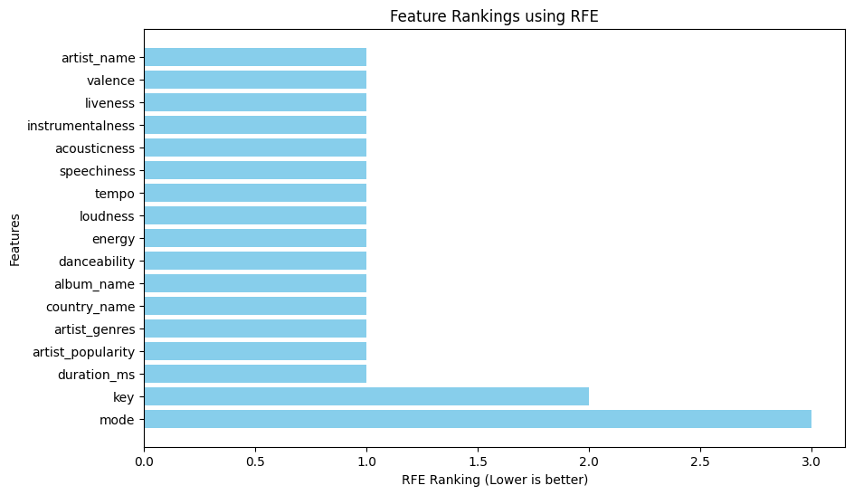

```python
# Get feature rankings
feature_ranking = rfe.ranking_

# Create a DataFrame for visualization
feature_importance_df = pd.DataFrame({'Feature': X_train.columns, 'Ranking': feature_ranking})

# Sort by ranking (lower ranking means more important)
feature_importance_df = feature_importance_df.sort_values(by='Ranking')

# Plot the rankings
plt.figure(figsize=(10, 6))
plt.barh(feature_importance_df['Feature'], feature_importance_df['Ranking'], color='skyblue')
plt.xlabel('RFE Ranking (Lower is better)')
plt.ylabel('Features')
plt.title('Feature Rankings using RFE')
plt.gca().invert_yaxis()  # Flip so most important features are on top
plt.show()
```